# 431 Class 03

Thomas E. Love, Ph.D.

2025-09-09

## Today’s Agenda

- Work in R with a data set (15 question Class 02 survey)
- Open RStudio, load in data and a template to write code
  - We’ll type only a little into the template today.
    - We’ll then look at the completed Quarto document.
    - We’ll also inspect and knit the Quarto file after all of the code is included.
  - Then we’ll start over again with the slides.

These slides walk through everything in the Quarto document.

## Today’s Files

From our [431-data page](https://github.com/THOMASELOVE/431-data), or our [Class 03 README (data folder)](https://github.com/THOMASELOVE/431-classes-2025/tree/main/class03/data), you should find:

- `431-first-r-template.qmd`
- `survey15_2014_to_2025.csv`

and

- `431-class03-all-code.qmd`

in addition to the usual slide materials.

## Today’s Plan

We’re using Quarto to gather together into a single document:

- the R code we build,
- text commenting on and reacting to that R code, and
- the output of the analyses we build.

Everything in these slides is also going into our Quarto file.

## Load packages and set theme

```r
library(janitor)
library(patchwork)
library(easystats)
library(tidyverse)

theme_set(theme_bw())
knitr::opts_chunk$set(comment = NA)
```

Loading packages in R is like opening up apps on your phone. We need to tell R that, in addition to the base functions available in the software, we also have other functions we want to use.

- Why are we loading these packages, in particular?

## On the tidyverse meta-package

- We will use the series of packages called the `tidyverse` in every Quarto file we create.
  - The `tidyverse` was developed (in part) by Hadley Wickham, Chief Scientist at Posit (makers of RStudio).
  - `dplyr` for data wrangling, cleaning and transformation
  - `ggplot2` is our main visualization package
  - other `tidyverse` packages help import data, work with factors and other common activities.

## More on today’s packages

- The `janitor` package has some tools for examining, cleaning and tabulating data (including `tabyl()` and `clean_names()`) that we’ll use regularly.
- The `patchwork` package will help us show multiple `ggplots` together.
- The `easystats` meta-package contains several other packages that will help us (especially) with building models and presenting our results.
- It’s helpful to load the `tidyverse` package last.

## Today’s Data

Our data come from the Quick 15-item Survey we did in Class 02 ([pdf in Class 02 README](https://github.com/THOMASELOVE/431-classes-2025/blob/main/class02/431_surveyhandout_1perstudent_2025-09-04.pdf)), which we’ve done (in various forms) since 2014.

- A copy of these data (in .csv format) is on our [431-data page](https://github.com/THOMASELOVE/431-data), and also linked on our [Class 03 README](https://github.com/THOMASELOVE/431-classes-2025/tree/main/class03/data).

So first, let’s ingest the data into R.

# Ingesting the data into R

## Our 431-data page

[figure not shown]

## We want `survey15_2014_to_2025.csv`

[figure not shown]

## Get the Raw version

[figure not shown]

## Raw .csv file suitable for saving

[figure not shown]

- So https://raw.githubusercontent.com/THOMASELOVE/431-data/refs/heads/main/data/survey15_2014_to_2025.csv is the URL we want.

## Tell R what URL you want to use

```r
url_raw <-
  "https://raw.githubusercontent.com/THOMASELOVE/431-data/refs/heads/main/data/survey15_2014_to_2025.csv"
```

- We assign the URL to `url_raw` with `<-`.
- This way, we have a shorter name to type.
- We’re going to ingest these data into a file called `surv15_raw`.

## Read in data from our `.csv` file

```r
surv15_raw <-
  read_csv(url_raw, show_col_types = FALSE) |>
  janitor::clean_names()
```

- The `<-` assignment arrow creates `surv15_raw`
- We use `read_csv` to read in the `survey15_2014_to_2025.csv` file from our [431-data page](https://github.com/THOMASELOVE/431-data).
- We use `show_col_types = FALSE` to suppress some unnecessary output describing the column types
- We use `clean_names()` from the janitor package
- We use the pipe `|>` to direct the information flow

## What is the result?

```r
surv15_raw
```

```
# A tibble: 656 × 23
   student glasses english statsofar love_htcm smoke h_left h_right handedness
     <dbl> <chr>   <chr>       <dbl>     <dbl> <dbl>  <dbl>   <dbl>      <dbl>
 1  202501 n       n               5       185     1      6      14       0.4
 2  202502 y       n               2       180     3      0      17       1
 3  202503 y       y               5       183     1      0      15       1
 4  202504 n       n               6       188     1     15       3      -0.67
 5  202505 y       n               5       183     1      0      13       1
 6  202506 n       y               5       185     1      9       9       0
 7  202507 n       y               6       185     3      4       8       0.33
 8  202508 y       y               5       182     1      6      13       0.37
 9  202509 y       n               6       182     1      0      20       1
10  202510 y       n               7       180     3      0      19       1
# ℹ 646 more rows
# ℹ 14 more variables: statfuture <dbl>, haircut <dbl>, lecture <dbl>,
#   alone <dbl>, height_in <dbl>, hand_span <dbl>, favcolor <chr>,
#   lastsleep <dbl>, pulse <dbl>, year <dbl>, lovetrueht <dbl>,
#   lovetrueage <dbl>, sex <chr>, ageguess <dbl>
```

## A more detailed look?

```r
glimpse(surv15_raw)
```

```
Rows: 656
Columns: 23
$ student     <dbl> 202501, 202502, 202503, 202504, 202505, 202506, 202507, 20…
$ glasses     <chr> "n", "y", "y", "n", "y", "n", "n", "y", "y", "y", "n", "n"…
$ english     <chr> "n", "n", "y", "n", "n", "y", "y", "y", "n", "n", "n", "y"…
$ statsofar   <dbl> 5, 2, 5, 6, 5, 5, 6, 5, 6, 7, 5, 4, 5, 3, 6, 5, 6, 4, 5, 5…
$ love_htcm   <dbl> 185, 180, 183, 188, 183, 185, 185, 182, 182, 180, 180, 188…
$ smoke       <dbl> 1, 3, 1, 1, 1, 1, 3, 1, 1, 3, 1, 1, 1, 1, 1, 1, 1, 1, 1, 1…
$ h_left      <dbl> 6, 0, 0, 15, 0, 9, 4, 6, 0, 0, 3, 5, 5, 1, 0, 16, 7, 0, 0,…
$ h_right     <dbl> 14, 17, 15, 3, 13, 9, 8, 13, 20, 19, 14, 15, 15, 9, 10, 2,…
$ handedness  <dbl> 0.40, 1.00, 1.00, -0.67, 1.00, 0.00, 0.33, 0.37, 1.00, 1.0…
$ statfuture  <dbl> 7, 6, 7, 6, 6, 6, 7, 6, 6, 7, 6, 5, 7, 5, 7, 6, 7, 7, 7, 6…
$ haircut     <dbl> 0, 20, 20, 0, 0, 0, 50, 0, 25, 32, 2, 20, 65, 30, 10, 300,…
$ lecture     <dbl> 2, 4, 2, 3, 3, 2, 3, 3, 3, 4, 2, 3, 2, 3, 3, 3, 3, 3, 5, 2…
$ alone       <dbl> 3, 3, 2, 3, 3, 2, 5, 3, 4, 3, 3, 3, 3, 3, 1, 2, 3, 3, 4, 4…
$ height_in   <dbl> 63.00, 68.00, 75.00, 62.00, 64.00, 71.00, 67.00, 63.00, 68…
$ hand_span   <dbl> 19.00, 20.00, 24.00, 20.10, 23.00, 23.50, 23.50, 20.25, 22…
$ favcolor    <chr> "yellow", "blue", "blue", "beige", "pink", "blue", "green"…
$ lastsleep   <dbl> 8.00, 7.50, 7.00, 7.11, 7.00, 6.50, 5.00, 5.50, 8.00, 5.00…
$ pulse       <dbl> 96, 76, 72, 88, 64, 51, 72, 88, 68, 92, 64, 96, 56, 20, 72…
$ year        <dbl> 2025, 2025, 2025, 2025, 2025, 2025, 2025, 2025, 2025, 2025…
$ lovetrueht  <dbl> 188, 188, 188, 188, 188, 188, 188, 188, 188, 188, 188, 188…
$ lovetrueage <dbl> 58.5, 58.5, 58.5, 58.5, 58.5, 58.5, 58.5, 58.5, 58.5, 58.5…
$ sex         <chr> NA, NA, NA, NA, NA, NA, NA, NA, NA, NA, NA, NA, NA, NA, NA…
$ ageguess    <dbl> NA, NA, NA, NA, NA, NA, NA, NA, NA, NA, NA, NA, NA, NA, NA…
```

# Six Key “Verbs” for Data Management

## 6 key data management “verbs”

- `filter()` chooses rows
- `select()` chooses columns
- `arrange()` sorts rows by values
- `mutate()` creates new columns
- `group_by()` manipulates groups of data
- `summarize()` provides numerical summaries

All of these are in the `dplyr` package; part of the **tidyverse**. See the [Data Transformation chapter of R4DS](https://r4ds.hadley.nz/data-transform.html).

## `filter()`

We use the `filter()` function to change which rows are present in the data, without changing the order.

```r
surv15_raw |> filter(year == "2025")
```

```
# A tibble: 53 × 23
   student glasses english statsofar love_htcm smoke h_left h_right handedness
     <dbl> <chr>   <chr>       <dbl>     <dbl> <dbl>  <dbl>   <dbl>      <dbl>
 1  202501 n       n               5       185     1      6      14       0.4
 2  202502 y       n               2       180     3      0      17       1
 3  202503 y       y               5       183     1      0      15       1
 4  202504 n       n               6       188     1     15       3      -0.67
 5  202505 y       n               5       183     1      0      13       1
 6  202506 n       y               5       185     1      9       9       0
 7  202507 n       y               6       185     3      4       8       0.33
 8  202508 y       y               5       182     1      6      13       0.37
 9  202509 y       n               6       182     1      0      20       1
10  202510 y       n               7       180     3      0      19       1
# ℹ 43 more rows
# ℹ 14 more variables: statfuture <dbl>, haircut <dbl>, lecture <dbl>,
#   alone <dbl>, height_in <dbl>, hand_span <dbl>, favcolor <chr>,
#   lastsleep <dbl>, pulse <dbl>, year <dbl>, lovetrueht <dbl>,
#   lovetrueage <dbl>, sex <chr>, ageguess <dbl>
```

## `select()`

We use the `select()` function to change which columns are present…

```r
surv15_raw |> select(student, glasses, lastsleep)
```

```
# A tibble: 656 × 3
   student glasses lastsleep
     <dbl> <chr>       <dbl>
 1  202501 n            8
 2  202502 y            7.5
 3  202503 y            7
 4  202504 n            7.11
 5  202505 y            7
 6  202506 n            6.5
 7  202507 n            5
 8  202508 y            5.5
 9  202509 y            8
10  202510 y            5
# ℹ 646 more rows
```

## `arrange()`

We use `arrange()` to change the order of the rows based on their values.

```r
surv15_raw |> arrange(height_in) |>
  select(student, height_in)
```

```
# A tibble: 656 × 2
   student height_in
     <dbl>     <dbl>
 1  201954        57
 2  202205        59
 3  202027        59
 4  202514        60
 5  202520        60
 6  202530        60
 7  202410        60
 8  202310        60
 9  202312        60
10  202109        60
# ℹ 646 more rows
```

## `mutate()`

We use `mutate()` to add new columns calculated from the existing columns.

```r
surv15_raw |> select(student, love_htcm, lovetrueht) |>
  mutate(ht_error = love_htcm - lovetrueht)
```

```
# A tibble: 656 × 4
   student love_htcm lovetrueht ht_error
     <dbl>     <dbl>      <dbl>    <dbl>
 1  202501       185        188       -3
 2  202502       180        188       -8
 3  202503       183        188       -5
 4  202504       188        188        0
 5  202505       183        188       -5
 6  202506       185        188       -3
 7  202507       185        188       -3
 8  202508       182        188       -6
 9  202509       182        188       -6
10  202510       180        188       -8
# ℹ 646 more rows
```

## `group_by()` and `summarize()`

We use `group_by()` to divide the data in groups of interest then use `summarize()` to obtain summaries.

```r
surv15_raw |>
  filter(complete.cases(height_in), year > 2018) |>
  group_by(year) |> summarize(n(), median(height_in))
```

```
# A tibble: 7 × 3
   year `n()` `median(height_in)`
  <dbl> <int>               <dbl>
1  2019    60                68
2  2020    66                66
3  2021    55                67.5
4  2022    54                68.5
5  2023    53                65
6  2024    54                67
7  2025    53                66
```

## Counting the `glasses` variable

```r
surv15_raw |> count(glasses)
```

```
# A tibble: 3 × 2
  glasses     n
  <chr>   <int>
1 n         144
2 y         256
3 <NA>      256
```

## Counting `glasses` and `english`

```r
surv15_raw |> count(glasses, english)
```

```
# A tibble: 9 × 3
  glasses english     n
  <chr>   <chr>   <int>
1 n       n          34
2 n       y         109
3 n       <NA>        1
4 y       n          57
5 y       y         197
6 y       <NA>        2
7 <NA>    n          47
8 <NA>    y         205
9 <NA>    <NA>        4
```

## Favorite Color in 2025?

```r
surv15_raw |>
    filter(year == "2025") |>
    tabyl(favcolor) |>
    adorn_pct_formatting()
```

```
     favcolor  n percent
        beige  1    1.9%
        black  4    7.5%
         blue 13   24.5%
   blue-green  1    1.9%
        green 11   20.8%
 light yellow  1    1.9%
       orange  1    1.9%
         pink  4    7.5%
       purple  9   17.0%
          red  3    5.7%
   sage green  1    1.9%
     sky blue  1    1.9%
        white  1    1.9%
       yellow  2    3.8%
```

## Using `summary()` on Quantities

```r
surv15_raw |>
  select(love_htcm, haircut, height_in, lastsleep) |>
  summary()
```

```
   love_htcm        haircut         height_in      lastsleep
 Min.   :152.0   Min.   :  0.00   Min.   :57.0   Min.   : 2.000
 1st Qu.:178.0   1st Qu.: 12.00   1st Qu.:64.0   1st Qu.: 6.000
 Median :183.0   Median : 25.00   Median :67.0   Median : 7.000
 Mean   :182.3   Mean   : 32.04   Mean   :67.1   Mean   : 6.911
 3rd Qu.:187.5   3rd Qu.: 40.00   3rd Qu.:70.0   3rd Qu.: 8.000
 Max.   :196.0   Max.   :300.00   Max.   :77.5   Max.   :12.000
 NA's   :385     NA's   :12       NA's   :9      NA's   :8
```

- Numerical summaries (five quantiles, plus the mean) for:
  - your guess of my height (in cm), last haircut price ($), your height (in inches), and last night’s hours of sleep
- How many observations are available?

## More Descriptive Summaries

```r
surv15_raw |>
  select(love_htcm, haircut, height_in, lastsleep) |>
  describe_distribution()
```

```
Variable  |   Mean |    SD | IQR |            Range | Skewness | Kurtosis |   n | n_Missing
-------------------------------------------------------------------------------------------
love_htcm | 182.26 |  6.39 |  10 | [152.00, 196.00] |    -1.14 |     3.61 | 271 |       385
haircut   |  32.04 | 35.23 |  28 |   [0.00, 300.00] |     3.03 |    13.81 | 644 |        12
height_in |  67.10 |  3.82 |   6 |   [57.00, 77.50] |     0.21 |    -0.54 | 647 |         9
lastsleep |   6.91 |  1.36 |   2 |    [2.00, 12.00] |    -0.35 |     0.75 | 648 |         8
```

## Even More Descriptive Summaries

```r
surv15_raw |>
  select(love_htcm, haircut, height_in, lastsleep) |>
  describe_distribution(centrality = "median")
```

```
Variable  | Median |   MAD | IQR |            Range | Skewness | Kurtosis |   n | n_Missing
-------------------------------------------------------------------------------------------
love_htcm |    183 |  7.41 |  10 | [152.00, 196.00] |    -1.14 |     3.61 | 271 |       385
haircut   |     25 | 22.24 |  28 |   [0.00, 300.00] |     3.03 |    13.81 | 644 |        12
height_in |     67 |  4.45 |   6 |   [57.00, 77.50] |     0.21 |    -0.54 | 647 |         9
lastsleep |      7 |  1.48 |   2 |    [2.00, 12.00] |    -0.35 |     0.75 | 648 |         8
```

# Manage the data into an analytic tibble called `surv15`

## Variables we’ll look at closely today

We’ll place these seven variables into our analytic data frame (tibble.)

- `student`: student identification (numerical code)
- `year`: indicates year when survey was taken (August)
- `english`: y = prefers to speak English, else n
- `smoke`: 1 = never smoker, 2 = quit, 3 = current
- `pulse`: pulse rate (beats per minute)
- `height_in`: student’s height (in inches)
- `haircut`: price of student’s last haircut (in $)

## Select our variables

```r
surv15 <- surv15_raw |>
    select(student, year, english, smoke,
           pulse, height_in, haircut)
```

- The `select()` function chooses the variables (columns) we want to keep in our new tibble called `surv15`.
- What should the result of this code look like?

## What do we have now?

```r
dim(surv15)
```

```
[1] 656   7
```

```r
surv15
```

```
# A tibble: 656 × 7
   student  year english smoke pulse height_in haircut
     <dbl> <dbl> <chr>   <dbl> <dbl>     <dbl>   <dbl>
 1  202501  2025 n           1    96        63       0
 2  202502  2025 n           3    76        68      20
 3  202503  2025 y           1    72        75      20
 4  202504  2025 n           1    88        62       0
 5  202505  2025 n           1    64        64       0
 6  202506  2025 y           1    51        71       0
 7  202507  2025 y           3    72        67      50
 8  202508  2025 y           1    88        63       0
 9  202509  2025 n           1    68        68      25
10  202510  2025 n           3    92        71      32
# ℹ 646 more rows
```

## Initial Numeric Summaries

- Is everything the “type” of variable it should be?
- Are we getting the summaries we want?

```r
summary(surv15)
```

```
    student            year        english              smoke
 Min.   :201401   Min.   :2014   Length:656         Min.   :1.000
 1st Qu.:201710   1st Qu.:2017   Class :character   1st Qu.:1.000
 Median :202014   Median :2020   Mode  :character   Median :1.000
 Mean   :201991   Mean   :2020                      Mean   :1.095
 3rd Qu.:202252   3rd Qu.:2022                      3rd Qu.:1.000
 Max.   :202553   Max.   :2025                      Max.   :3.000
                                                    NA's   :2
     pulse          height_in       haircut
 Min.   : 20.00   Min.   :57.0   Min.   :  0.00
 1st Qu.: 65.00   1st Qu.:64.0   1st Qu.: 12.00
 Median : 72.00   Median :67.0   Median : 25.00
 Mean   : 74.02   Mean   :67.1   Mean   : 32.04
 3rd Qu.: 80.00   3rd Qu.:70.0   3rd Qu.: 40.00
 Max.   :124.00   Max.   :77.5   Max.   :300.00
 NA's   :79       NA's   :9      NA's   :12
```

## What should we be seeing?

- Categorical variables should list the categories, with associated counts.
  - To accomplish this, the variable needs to be represented in R with a `factor`, rather than as a `character` or `numeric` variable.
- Quantitative variables should show the minimum, median, mean, maximum, etc.

```r
names(surv15)
```

```
[1] "student"   "year"      "english"   "smoke"     "pulse"     "height_in"
[7] "haircut"
```

## Categorical variables as factors

We want the `year` and `smoke` information treated as categorical, rather than as quantitative, and the `english` information as a factor, too. Also, do we want to summarize the student ID codes?

- We use the `mutate()` function to help with this.

```r
surv15 <- surv15 |>
    mutate(year = as_factor(year),
           smoke = as_factor(smoke),
           english = as_factor(english),
           student = as.character(student))
```

- Note that it’s `as_factor()` but `as.character()`. Sigh.

## Next step: Recheck the summaries and do range checks

- Do these summaries make sense?
- Are the minimum and maximum values appropriate?
- How much missingness are we to deal with?

## Now, how’s our summary?

```r
summary(surv15)
```

```
   student               year     english     smoke         pulse
 Length:656         2020   : 67   n   :138   1   :605   Min.   : 20.00
 Class :character   2016   : 64   y   :511   2   : 36   1st Qu.: 65.00
 Mode  :character   2019   : 61   NA's:  7   3   : 13   Median : 72.00
                    2021   : 58              NA's:  2   Mean   : 74.02
                    2024   : 56                         3rd Qu.: 80.00
                    2022   : 54                         Max.   :124.00
                    (Other):296                         NA's   :79
   height_in       haircut
 Min.   :57.0   Min.   :  0.00
 1st Qu.:64.0   1st Qu.: 12.00
 Median :67.0   Median : 25.00
 Mean   :67.1   Mean   : 32.04
 3rd Qu.:70.0   3rd Qu.: 40.00
 Max.   :77.5   Max.   :300.00
 NA's   :9      NA's   :12
```

- Some things to look for appear on the next slide.

## What to look for…

- Are we getting counts for all variables that are categorical?
  - Do the category levels make sense?
- Are we getting means and medians for all variables that are quantities?
  - Do the minimum and maximum values make sense for each of these quantities?
- Which variables have missing data, as indicated by `NA's`?

## The summary for `year` is an issue

- Just to fill in the gap left by the `summary()` result, how many students responded each year?

```r
surv15 |> tabyl(year) |> adorn_totals() |> adorn_pct_formatting()
```

```
  year   n percent
  2014  42    6.4%
  2015  49    7.5%
  2016  64    9.8%
  2017  48    7.3%
  2018  51    7.8%
  2019  61    9.3%
  2020  67   10.2%
  2021  58    8.8%
  2022  54    8.2%
  2023  53    8.1%
  2024  56    8.5%
  2025  53    8.1%
 Total 656  100.0%
```

# Three Exploratory Questions

## Three Exploratory Questions

1. What is the distribution of pulse rates among students in 431 since 2014?
2. Does the distribution of student heights change materially over time?
3. Is the Normal distribution a good model for student heights? How about for student haircut prices?

# Question 1

## Question 1

What is the distribution of pulse rates among students in 431 since 2014?

```r
surv15 |> tabyl(pulse) |> adorn_pct_formatting()
```

```
 pulse  n percent valid_percent
    20  1    0.2%          0.2%
    30  1    0.2%          0.2%
    33  1    0.2%          0.2%
    44  1    0.2%          0.2%
    46  1    0.2%          0.2%
    48  4    0.6%          0.7%
    50  4    0.6%          0.7%
    51  1    0.2%          0.2%
    52  6    0.9%          1.0%
    54  6    0.9%          1.0%
    55  2    0.3%          0.3%
    56 13    2.0%          2.3%
    57  1    0.2%          0.2%
    58  5    0.8%          0.9%
```

[output cut: 43 more lines]

## Histogram, first try

- What is the distribution of student `pulse` rates?

```r
ggplot(data = surv15, aes(x = pulse)) +
    geom_histogram(bins = 15, fill = "royalblue",  col = "seagreen1")
```

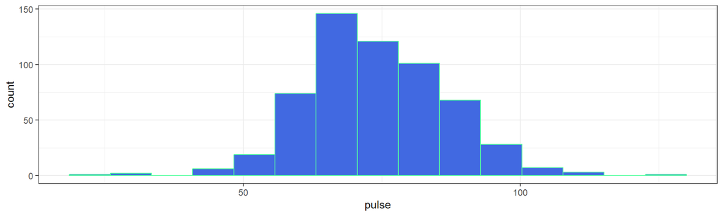

## Describing the Pulse Rates

How might we describe this distribution?

- What is the center?
- How much of a range around that center do we see? How spread out are the data?
- What is the shape of this distribution?
  - Is it symmetric, or is it skewed to the left or to the right?

(Histogram is replotted on the next slide)

## Histogram (with warning suppressed)

```r
ggplot(data = surv15, aes(x = pulse)) +
    geom_histogram(bins = 15, fill = "royalblue", col = "seagreen1")
```

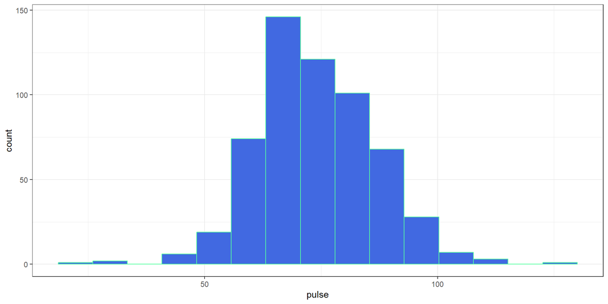

## Some Key Numerical Summaries

```r
surv15 |> select(pulse) |> summary()
```

```
     pulse
 Min.   : 20.00
 1st Qu.: 65.00
 Median : 72.00
 Mean   : 74.02
 3rd Qu.: 80.00
 Max.   :124.00
 NA's   :79
```

```r
length(surv15$pulse)
```

```
[1] 656
```

```r
sd(surv15$pulse, na.rm = TRUE)
```

```
[1] 12.69663
```

```r
mad(surv15$pulse, na.rm = TRUE)
```

```
[1] 11.8608
```

- Do these summaries help us describe the data?

## Histogram, version 2

```r
dat1 <- surv15 |>
  filter(complete.cases(pulse))

ggplot(data = dat1, aes(x = pulse)) +
    geom_histogram(fill = "seagreen", col = "white", bins = 20) +
    labs(title = "Pulse Rates of Dr. Love's students",
         subtitle = "2014 - 2025",
         y = "Number of Students",
         x = "Pulse Rate (beats per minute)")
```

- How did we deal with missing data?
- How did we add axis labels and titles to the plot?
- What is the distinction between `fill` and `col`?
- How many bins should we use?

## Histogram, version 2

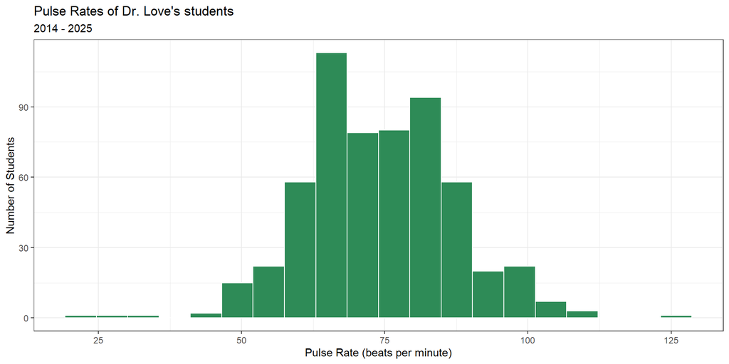

# Question 2

## Question 2

Does the distribution of student heights change over time?

(Plot shown on next slide)

```r
ggplot(surv15, aes(x = year, y = height_in)) +
  geom_point(alpha = 0.7, color = "forestgreen")
```

## Question 2

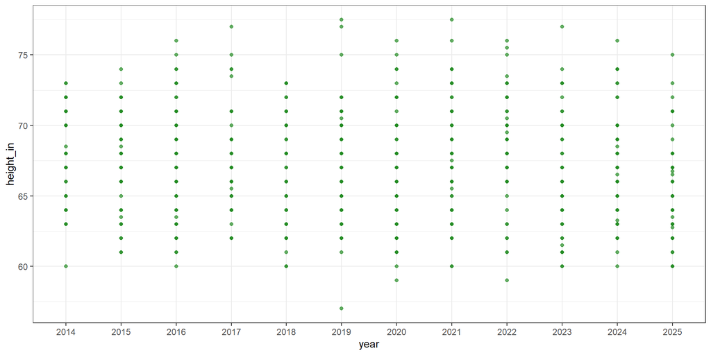

## Yearly Five-Number Summaries

```r
surv15 |>
    filter(complete.cases(height_in)) |>
    group_by(year) |>
    summarize(n = n(), min = min(height_in), q25 = quantile(height_in, 0.25),
              median = median(height_in), q75 = quantile(height_in, 0.75),
              max = max(height_in))
```

- What should this produce? (Results on next slide)

## Yearly Five-Number Summaries

```
# A tibble: 12 × 7
   year      n   min   q25 median   q75   max
   <fct> <int> <dbl> <dbl>  <dbl> <dbl> <dbl>
 1 2014     40    60  64.8   68    71    73
 2 2015     49    61  65     68    70    74
 3 2016     64    60  64     67    70    76
 4 2017     48    62  65     67    69    77
 5 2018     51    60  63     66    70    73
 6 2019     60    57  65     68    70    77.5
 7 2020     66    59  63     66    69.8  76
 8 2021     55    60  64.5   67.5  71    77.5
 9 2022     54    59  66     68.5  70.4  76
10 2023     53    60  64     65    69    77
11 2024     54    60  64     67    69.8  76
12 2025     53    60  63     66    68    75
```

- Do these summaries change materially over time?
- What are these summaries, specifically?

## Five-Number Summary

- Key summaries based on percentiles / quantiles
  - minimum = 0th, maximum = 100th, median = 50th
  - quartiles (25th, 50th and 75th percentiles)
  - Range is maximum - minimum
  - IQR (inter-quartile range) is 75th - 25th percentile
- These summaries are generally more resistant to outliers than mean, standard deviation
- Form the elements of a boxplot (box-and-whisker plot)

## Boxplot of Heights by Year

```r
dat1 <- surv15 |>
    filter(complete.cases(height_in))

ggplot(data = dat1, aes(x = year, y = height_in)) +
    geom_boxplot() +
    labs(title = "Heights of Dr. Love's students, by year",
         subtitle = "2014 - 2025", x = "Year", y = "Height (in inches)")
```

- How did we deal with missing data here?

## Boxplot of Heights by Year

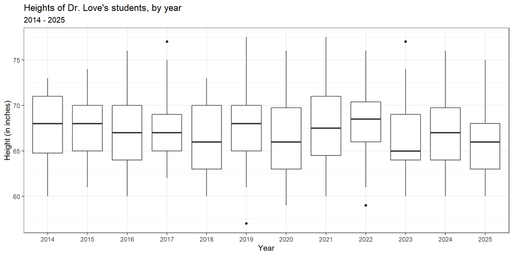

## Thinking about the Boxplot

- Box covers the middle half of the data (25th and 75th percentiles), and the solid line indicates the median
- Whiskers extend from the quartiles to the most extreme values that are not judged by **Tukey’s** “fences” method to be candidate outliers
  - Fences are drawn at 25th percentile - 1.5 IQR and 75th percentile + 1.5 IQR
- Are any values candidate outliers by this method?
- Was it important to change `year` to a factor earlier?

## Adding a Violin to the Boxplot

- When we’d like to better understand the shape of a distribution, we can amplify the boxplot.

```r
dat1 <- surv15 |>
    filter(complete.cases(height_in))

ggplot(data = dat1, aes(x = year, y = height_in)) +
    geom_violin() +
    geom_boxplot(aes(fill = year), width = 0.3) +
    guides(fill = "none") +
    scale_fill_viridis_d(alpha = 0.3) +
    labs(title = "Heights of Dr. Love's students, by year",
         subtitle = "2014 - 2025", x = "Year", y = "Height (in inches)")
```

## Adding a Violin to the Boxplot

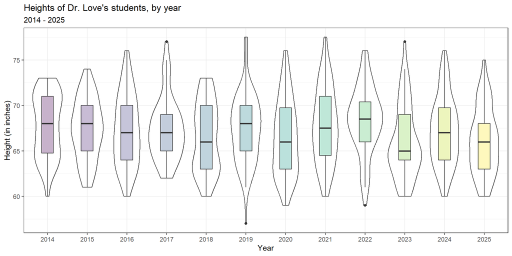

## Boxplot with Violin

- How did we change the boxplot when we added the violin?
- What would happen if we added the boxplot first and the violin second?
- What does `guides(fill = "none")` do?
- What does `scale_fill_viridis_d(alpha = 0.3)` do?

## Key Numerical Summaries

```r
surv15 |>
    filter(complete.cases(height_in)) |>
    group_by(year) |>
    summarize(n = n(), mean = mean(height_in), sd = sd(height_in),
              median = median(height_in), mad = mad(height_in))
```

```
# A tibble: 12 × 6
   year      n  mean    sd median   mad
   <fct> <int> <dbl> <dbl>  <dbl> <dbl>
 1 2014     40  67.8  3.46   68    4.45
 2 2015     49  67.3  3.32   68    2.97
 3 2016     64  67.2  3.86   67    4.45
 4 2017     48  67.4  3.46   67    2.97
 5 2018     51  66.5  3.81   66    4.45
 6 2019     60  67.4  3.83   68    4.45
 7 2020     66  66.4  4.09   66    4.45
 8 2021     55  67.8  4.13   67.5  5.19
 9 2022     54  68.4  3.74   68.5  3.71
10 2023     53  66.0  4.00   65    2.97
11 2024     54  67.2  3.70   67    4.45
12 2025     53  66.0  3.65   66    3.71
```

# Question 3

## Question 3

Are the data on student heights in 2025 well described by a Normal distribution?

- Can we use a mean and standard deviation to describe the center and spread of the data effectively?

## A Normal distribution

This is a Normal (or Gaussian) distribution with mean 150 and standard deviation 30.

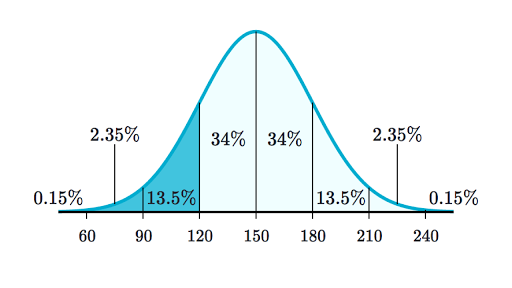

- A Normal distribution is completely specified by its mean and standard deviation. The “bell shape” doesn’t change.

## Summarizing Quantitative Data

If the data followed a Normal model,

- we would be justified in using the sample **mean** to describe the center, and
- in using the sample **standard deviation** to describe the spread (variation.)

But it is often the case that these measures aren’t robust enough, because the data show meaningful skew (asymmetry), or the data have lighter or heavier tails than a Normal model would predict.

## The Empirical Rule for Approximately Normal Distributions

If the data followed a Normal distribution,

- approximately 68% of the data would be within 1 SD of the mean,
- approximately 95% of the data would be within 2 SD of the mean, while
- essentially all (99.7%) of the data would be within 3 SD of the mean.

## Empirical Rule & 2025 Student Heights

```r
dat2 <- surv15 |>
  filter(complete.cases(height_in),
         year == "2025")

describe_distribution(dat2$height_in)
```

```
 Mean |   SD | IQR |          Range | Skewness | Kurtosis |  n | n_Missing
--------------------------------------------------------------------------
66.05 | 3.65 |   5 | [60.00, 75.00] |     0.34 |    -0.55 | 53 |         0
```

In 2025, we had 53 students whose `height_in` was available, with mean 66.05 inches (167.8 cm) and standard deviation 3.65 inches (9.3 cm).

Consider a picture of the data…

## Histogram of 2025 Student Heights

```r
dat2 <- surv15 |>
  filter(complete.cases(height_in)) |>
  filter(year == "2025")

ggplot(data = dat2, aes(x = height_in)) +
    geom_histogram(fill = "salmon", col = "white", binwidth = 2) +
    labs(title = "Heights of Dr. Love's students",
         subtitle = "2025 (n = 53 students with height data)",
         y = "Number of Students", x = "Height (inches)")
```

- How did we use the two `filter()` statements?
- Why might I have changed from specifying `bins` to `binwidth` here?

## Histogram of 2025 Student Heights

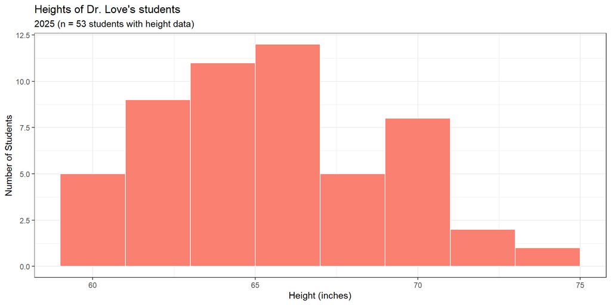

## Checking the 1-SD Empirical Rule

- Of the 53 students in 2025 with heights, how many were within 1 SD of the mean?
  - Mean = 66.05, SD = 3.65.
  - 66.05 - 3.65 = 62.4; 66.05 + 3.65 = 69.7 inches

```r
surv15 |> filter(complete.cases(height_in)) |>
    filter(year == "2025") |>
    count(height_in >= 62.4 & height_in <= 69.7)
```

```
# A tibble: 2 × 2
  `height_in >= 62.4 & height_in <= 69.7`     n
  <lgl>                                   <int>
1 FALSE                                      20
2 TRUE                                       33
```

```r
33/(33+20)
```

```
[1] 0.6226415
```

## 2-SD Empirical Rule

- How many of the 53 `height_in` values gathered in 2025 were between 66.05 - 2(3.65) = 58.75 and 66.05 + 2(3.65) = 73.35 inches?

```r
surv15 |> filter(complete.cases(height_in)) |>
    filter(year == "2025") |>
    count(height_in >= 58.75 & height_in <= 73.35)
```

```
# A tibble: 2 × 2
  `height_in >= 58.75 & height_in <= 73.35`     n
  <lgl>                                     <int>
1 FALSE                                         1
2 TRUE                                         52
```

```r
52/(52+1)
```

```
[1] 0.9811321
```

## 3-SD Empirical Rule

- How many of the 53 `height_in` values gathered in 2025 were between 66.05 - 3(3.65) = 55.1 and 66.05 + 3(3.65) = 77.0 inches?

```r
surv15 |> filter(complete.cases(height_in)) |>
    filter(year == "2025") |>
    count(height_in >= 55.1 & height_in <= 77.0)
```

```
# A tibble: 1 × 2
  `height_in >= 55.1 & height_in <= 77`     n
  <lgl>                                 <int>
1 TRUE                                     53
```

```r
53/(53+0)
```

```
[1] 1
```

## Empirical Rule Table for 2025 data

| Range | “Normal” | `height_in` | `haircut` |
| --- | --- | --- | --- |
| $\bar{x} \pm s$ | ~68% | $\frac{33}{53}$ = 62.3% | $\frac{48}{53}$ = 90.6% |
| $\bar{x} \pm 2\times s$ | ~95% | $\frac{52}{53}$ = 98.1% | $\frac{51}{53}$ = 96.2% |
| $\bar{x} \pm 3\times s$ | ~99.7% | $\frac{53}{53}$ = 100% | $\frac{51}{53}$ = 96.2% |

## Boxplots: Height & Haircut Price

```r
dat2 <- surv15 |> filter(complete.cases(height_in), year == "2025")

p2 <- ggplot(data = dat2, aes(x = "height (inches)", y = height_in)) +
  geom_violin() + geom_boxplot(width = 0.3, fill = "tomato") +
  labs(title = "Boxplot of 2025 Student Heights", x = "")

dat3 <- surv15 |> filter(complete.cases(haircut), year == "2025")

p3 <- ggplot(data = dat3, aes(x = "haircut ($)", y = haircut)) +
  geom_violin() + geom_boxplot(width = 0.3, fill = "dodgerblue") +
  labs(title = "Boxplot of 2025 Haircut Prices", x = "")

p2 + p3 +
  plot_annotation(title = "2025 15-Question Survey Data")
```

- What is `width = 0.3` doing? How about the `x` options?
- What am I doing with `p2 + p3 + plot_annotation`?
- What should this look like?

## Boxplots: Height & Haircut Price

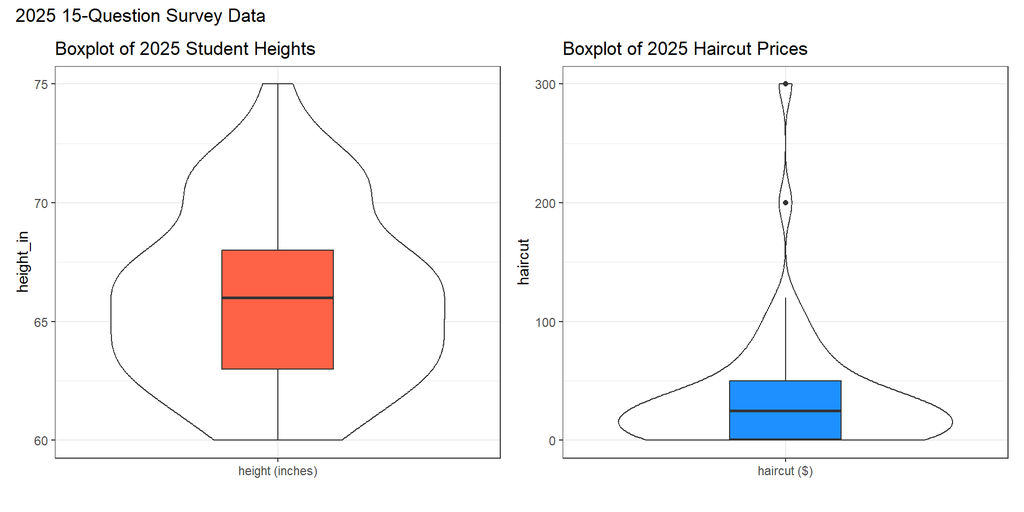

## Mean/SD vs. Median/MAD

If the data are approximately Normally distributed (like `height_in` and `pulse`) we can safely use the sample mean and standard deviation as summaries. If not, then …

- The median is a more robust summary of the center.
- For spread, try the median absolute deviation<sup>1</sup>.

[output not shown]

[^1]: MAD scaled here to equal the standard deviation when data follow the Normal.

# Thoughts So Far

## Question 1 Thoughts

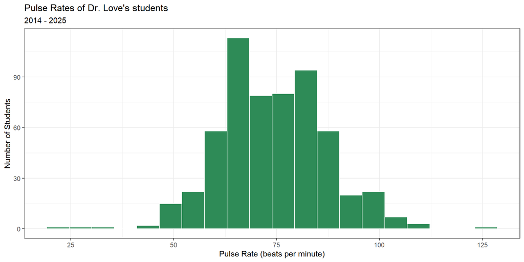

## Question 2 Thoughts

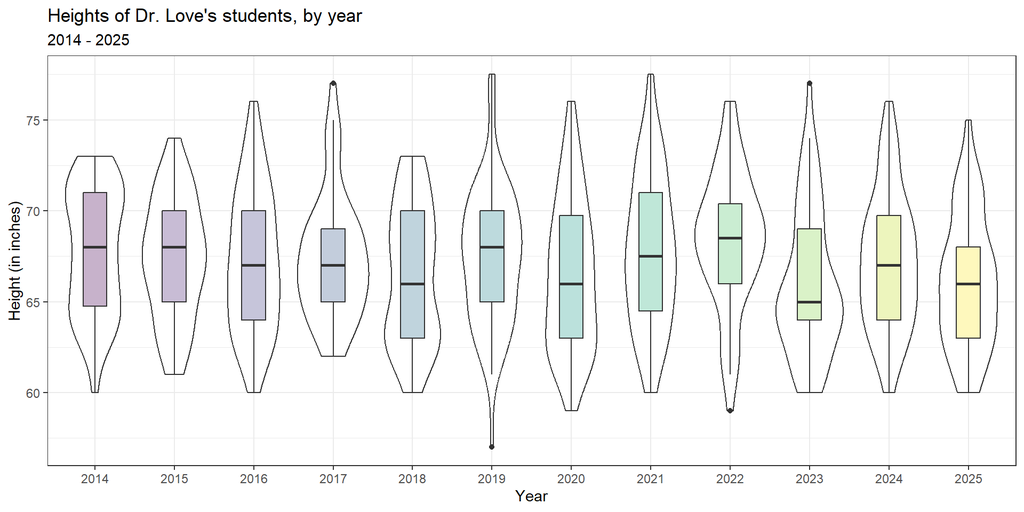

## Question 3 Thoughts

1. Are the data on student heights in 2025 well described by a Normal distribution?
   - To some extent, yes. Mean was 66.05 inches, SD = 3.65 inches, with median = 66 inches, MAD = 3.7 inches.
2. What about haircut prices?
   - Not well described by a Normal distribution. Some very large outliers, and many results gathered close to 0, which describes right skew, where the mean (38.36 USD) substantially exceeds the median (25.00 USD.)

## Next Time

- Additional Exploration of the “15-Question Survey” data
- Dealing with categorical data
- Thinking about associations, and modeling them
- Comparing means / medians of two “paired” samples